# R Notebook

Import packages

```r
library(dplyr)
```

```r
library (readxl)
```

```r
library (tidyverse)
```

```r
library(ggplot2)
```

Import 1996 MICP data

```r
mandaclipped1996 <- read.csv("~/Library/CloudStorage/OneDrive-UniversityofExeter/Global Sustainability Solutions/Dissertation/Global Mangrove Watch Datasets /CSV Lamu Clipped Data files/MANDACLIPPEDDATA/mandaclipped1996NEW.csv", header=TRUE)
mandaclipped1996
```

| PXLVAL | clipped2007data | X1996area |
| --- | --- | --- |
| 1 | 3037.052 | 38 |
| 1 | 607.410 | 607 |
| 1 | 18222.269 | 18222 |
| 1 | 607.408 | 319 |
| 1 | 2429.631 | 2430 |
| 1 | 607.408 | 607 |
| 1 | 607.408 | 607 |
| 1 | 495644.366 | 444608 |
| 1 | 194369.558 | 187681 |
| 1 | 8492709.084 | 981294 |

[output cut: 1 more lines]

Rename 1996 area column

```r
names(mandaclipped1996)[names(mandaclipped1996) == 'X1996area'] <- 'mangroves'
mandaclipped1996
```

| PXLVAL | clipped2007data | mangroves |
| --- | --- | --- |
| 1 | 3037.052 | 38 |
| 1 | 607.410 | 607 |
| 1 | 18222.269 | 18222 |
| 1 | 607.408 | 319 |
| 1 | 2429.631 | 2430 |
| 1 | 607.408 | 607 |
| 1 | 607.408 | 607 |
| 1 | 495644.366 | 444608 |
| 1 | 194369.558 | 187681 |
| 1 | 8492709.084 | 981294 |

[output cut: 1 more lines]

Create a 1996 year

```r
mandaclipped1996 <- cbind(mandaclipped1996, year="1996")
mandaclipped1996
```

| PXLVAL | clipped2007data | mangroves | year |
| --- | --- | --- | --- |
| 1 | 3037.052 | 38 | 1996 |
| 1 | 607.410 | 607 | 1996 |
| 1 | 18222.269 | 18222 | 1996 |
| 1 | 607.408 | 319 | 1996 |
| 1 | 2429.631 | 2430 | 1996 |
| 1 | 607.408 | 607 | 1996 |
| 1 | 607.408 | 607 | 1996 |
| 1 | 495644.366 | 444608 | 1996 |
| 1 | 194369.558 | 187681 | 1996 |
| 1 | 8492709.084 | 981294 | 1996 |

[output cut: 1 more lines]

Drop columns

```r
mandaclipped1996 = subset(mandaclipped1996,select = -c(PXLVAL, clipped2007data))
mandaclipped1996
```

|  | mangroves | year |
| --- | --- | --- |
| 1 | 38 | 1996 |
| 2 | 607 | 1996 |
| 3 | 18222 | 1996 |
| 4 | 319 | 1996 |
| 5 | 2430 | 1996 |
| 6 | 607 | 1996 |
| 7 | 607 | 1996 |
| 8 | 444608 | 1996 |
| 9 | 187681 | 1996 |
| 10 | 981294 | 1996 |

[output cut: 1 more lines]

Add 2007 MICP data

```r
mandaclipped2007 <- read.csv("~/Library/CloudStorage/OneDrive-UniversityofExeter/Global Sustainability Solutions/Dissertation/Global Mangrove Watch Datasets /CSV Lamu Clipped Data files/MANDACLIPPEDDATA/Mandaclipped2007NEW.csv", header=TRUE)
mandaclipped2007
```

| PXLVAL | clipped2007data | X2007 |
| --- | --- | --- |
| 1 | 607.410 | 607 |
| 1 | 18222.269 | 18222 |
| 1 | 607.408 | 607 |
| 1 | 607.408 | 319 |
| 1 | 2429.631 | 2430 |
| 1 | 607.408 | 607 |
| 1 | 495644.366 | 458459 |
| 1 | 194369.558 | 194363 |
| 1 | 607.403 | 607 |
| 1 | 8492709.084 | 982509 |

[output cut: 1 more lines]

Rename 2007 area column

```r
names(mandaclipped2007)[names(mandaclipped2007) == 'X2007'] <- 'mangroves'
mandaclipped2007
```

| PXLVAL | clipped2007data | mangroves |
| --- | --- | --- |
| 1 | 607.410 | 607 |
| 1 | 18222.269 | 18222 |
| 1 | 607.408 | 607 |
| 1 | 607.408 | 319 |
| 1 | 2429.631 | 2430 |
| 1 | 607.408 | 607 |
| 1 | 495644.366 | 458459 |
| 1 | 194369.558 | 194363 |
| 1 | 607.403 | 607 |
| 1 | 8492709.084 | 982509 |

[output cut: 1 more lines]

Create a 2007 year

```r
mandaclipped2007 <- cbind(mandaclipped2007, year="2007")
mandaclipped2007
```

| PXLVAL | clipped2007data | mangroves | year |
| --- | --- | --- | --- |
| 1 | 607.410 | 607 | 2007 |
| 1 | 18222.269 | 18222 | 2007 |
| 1 | 607.408 | 607 | 2007 |
| 1 | 607.408 | 319 | 2007 |
| 1 | 2429.631 | 2430 | 2007 |
| 1 | 607.408 | 607 | 2007 |
| 1 | 495644.366 | 458459 | 2007 |
| 1 | 194369.558 | 194363 | 2007 |
| 1 | 607.403 | 607 | 2007 |
| 1 | 8492709.084 | 982509 | 2007 |

[output cut: 1 more lines]

drop columns

```r
mandaclipped2007 = subset(mandaclipped2007,select = -c(PXLVAL, clipped2007data))
mandaclipped2007
```

|  | mangroves | year |
| --- | --- | --- |
| 1 | 607 | 2007 |
| 2 | 18222 | 2007 |
| 3 | 607 | 2007 |
| 4 | 319 | 2007 |
| 5 | 2430 | 2007 |
| 6 | 607 | 2007 |
| 7 | 458459 | 2007 |
| 8 | 194363 | 2007 |
| 9 | 607 | 2007 |
| 10 | 982509 | 2007 |

[output cut: 1 more lines]

Import 2008 MICP data

```r
mandaclipped2008 <- read_excel("~/Library/CloudStorage/OneDrive-UniversityofExeter/Global Sustainability Solutions/Dissertation/Global Mangrove Watch Datasets /CSV Lamu Clipped Data files/MANDACLIPPEDDATA/MANDACLIP2008NEW.xls")
mandaclipped2008
```

| PXLVAL | clipped2008 | 2008 |
| --- | --- | --- |
| 1 | 607.410 | 607 |
| 1 | 18222.269 | 18222 |
| 1 | 4859.267 | 4859 |
| 1 | 607.408 | 607 |
| 1 | 607.408 | 319 |
| 1 | 3644.447 | 3644 |
| 1 | 1214.812 | 555 |
| 1 | 484103.667 | 457524 |
| 1 | 196191.766 | 196192 |
| 1 | 8496961.011 | 981294 |

[output cut: 1 more lines]

Rename 2008 area column

```r
names(mandaclipped2008)[names(mandaclipped2008) == '2008'] <- 'mangroves'
mandaclipped2008
```

| PXLVAL | clipped2008 | mangroves |
| --- | --- | --- |
| 1 | 607.410 | 607 |
| 1 | 18222.269 | 18222 |
| 1 | 4859.267 | 4859 |
| 1 | 607.408 | 607 |
| 1 | 607.408 | 319 |
| 1 | 3644.447 | 3644 |
| 1 | 1214.812 | 555 |
| 1 | 484103.667 | 457524 |
| 1 | 196191.766 | 196192 |
| 1 | 8496961.011 | 981294 |

[output cut: 1 more lines]

Create 2008 year

```r
mandaclipped2008 <- cbind(mandaclipped2008, year="2008")
mandaclipped2008
```

| PXLVAL | clipped2008 | mangroves | year |
| --- | --- | --- | --- |
| 1 | 607.410 | 607 | 2008 |
| 1 | 18222.269 | 18222 | 2008 |
| 1 | 4859.267 | 4859 | 2008 |
| 1 | 607.408 | 607 | 2008 |
| 1 | 607.408 | 319 | 2008 |
| 1 | 3644.447 | 3644 | 2008 |
| 1 | 1214.812 | 555 | 2008 |
| 1 | 484103.667 | 457524 | 2008 |
| 1 | 196191.766 | 196192 | 2008 |
| 1 | 8496961.011 | 981294 | 2008 |

[output cut: 1 more lines]

Drop columns

```r
mandaclipped2008 = subset(mandaclipped2008,select = -c(PXLVAL, clipped2008))
mandaclipped2008
```

|  | mangroves | year |
| --- | --- | --- |
| 1 | 607 | 2008 |
| 2 | 18222 | 2008 |
| 3 | 4859 | 2008 |
| 4 | 607 | 2008 |
| 5 | 319 | 2008 |
| 6 | 3644 | 2008 |
| 7 | 555 | 2008 |
| 8 | 457524 | 2008 |
| 9 | 196192 | 2008 |
| 10 | 981294 | 2008 |

[output cut: 1 more lines]

Import 2009 MICP data

```r
mandaclipped2009 <- read.csv("~/Library/CloudStorage/OneDrive-UniversityofExeter/Global Sustainability Solutions/Dissertation/Global Mangrove Watch Datasets /CSV Lamu Clipped Data files/MANDACLIPPEDDATA/mandaclipped2009NEW.csv", header=TRUE)
mandaclipped2009
```

| PXLVAL | clipped2009data | X2009are |
| --- | --- | --- |
| 1 | 17614.859 | 17615 |
| 1 | 607.408 | 607 |
| 1 | 607.408 | 319 |
| 1 | 4251.855 | 4252 |
| 1 | 607.406 | 607 |
| 1 | 1214.812 | 555 |
| 1 | 471348.149 | 456008 |
| 1 | 194976.947 | 194977 |
| 1 | 8521257.250 | 983116 |
| 1 | 1214.821 | 38 |

[output cut: 1 more lines]

Rename 2009 area column

```r
names(mandaclipped2009)[names(mandaclipped2009) == 'X2009are'] <- 'mangroves'
mandaclipped2009
```

| PXLVAL | clipped2009data | mangroves |
| --- | --- | --- |
| 1 | 17614.859 | 17615 |
| 1 | 607.408 | 607 |
| 1 | 607.408 | 319 |
| 1 | 4251.855 | 4252 |
| 1 | 607.406 | 607 |
| 1 | 1214.812 | 555 |
| 1 | 471348.149 | 456008 |
| 1 | 194976.947 | 194977 |
| 1 | 8521257.250 | 983116 |
| 1 | 1214.821 | 38 |

[output cut: 1 more lines]

Create 2009 year

```r
mandaclipped2009 <- cbind(mandaclipped2009, year="2009")
mandaclipped2009
```

| PXLVAL | clipped2009data | mangroves | year |
| --- | --- | --- | --- |
| 1 | 17614.859 | 17615 | 2009 |
| 1 | 607.408 | 607 | 2009 |
| 1 | 607.408 | 319 | 2009 |
| 1 | 4251.855 | 4252 | 2009 |
| 1 | 607.406 | 607 | 2009 |
| 1 | 1214.812 | 555 | 2009 |
| 1 | 471348.149 | 456008 | 2009 |
| 1 | 194976.947 | 194977 | 2009 |
| 1 | 8521257.250 | 983116 | 2009 |
| 1 | 1214.821 | 38 | 2009 |

[output cut: 1 more lines]

Drop Columns

```r
mandaclipped2009 = subset(mandaclipped2009,select = -c(PXLVAL, clipped2009data))
mandaclipped2009
```

|  | mangroves | year |
| --- | --- | --- |
| 1 | 17615 | 2009 |
| 2 | 607 | 2009 |
| 3 | 319 | 2009 |
| 4 | 4252 | 2009 |
| 5 | 607 | 2009 |
| 6 | 555 | 2009 |
| 7 | 456008 | 2009 |
| 8 | 194977 | 2009 |
| 9 | 983116 | 2009 |
| 10 | 38 | 2009 |

[output cut: 1 more lines]

Import 2010 MICP data

```r
mandaclipped2010 <- read_excel("~/Library/CloudStorage/OneDrive-UniversityofExeter/Global Sustainability Solutions/Dissertation/Global Mangrove Watch Datasets /CSV Lamu Clipped Data files/MANDACLIPPEDDATA/MANDACLIP2010NEW.xls")
mandaclipped2010
```

| PXLVAL | 2010clippedlamu | 2010area |
| --- | --- | --- |
| 1 | 17614.859 | 17615 |
| 1 | 1214.816 | 1215 |
| 1 | 607.408 | 607 |
| 1 | 607.406 | 607 |
| 1 | 1214.812 | 555 |
| 1 | 467703.711 | 454502 |
| 1 | 194976.947 | 194906 |
| 1 | 8512753.538 | 983116 |
| 1 | 1214.821 | 38 |

Rename 2010 area column

```r
names(mandaclipped2010)[names(mandaclipped2010) == '2010area'] <- 'mangroves'
mandaclipped2010
```

| PXLVAL | 2010clippedlamu | mangroves |
| --- | --- | --- |
| 1 | 17614.859 | 17615 |
| 1 | 1214.816 | 1215 |
| 1 | 607.408 | 607 |
| 1 | 607.406 | 607 |
| 1 | 1214.812 | 555 |
| 1 | 467703.711 | 454502 |
| 1 | 194976.947 | 194906 |
| 1 | 8512753.538 | 983116 |
| 1 | 1214.821 | 38 |

```r
names(mandaclipped2010)[names(mandaclipped2010) == '2010clippedlamu'] <- 'delete'
mandaclipped2010
```

| PXLVAL | delete | mangroves |
| --- | --- | --- |
| 1 | 17614.859 | 17615 |
| 1 | 1214.816 | 1215 |
| 1 | 607.408 | 607 |
| 1 | 607.406 | 607 |
| 1 | 1214.812 | 555 |
| 1 | 467703.711 | 454502 |
| 1 | 194976.947 | 194906 |
| 1 | 8512753.538 | 983116 |
| 1 | 1214.821 | 38 |

Create 2010 year

```r
mandaclipped2010 <- cbind(mandaclipped2010, year="2010")
mandaclipped2010
```

| PXLVAL | delete | mangroves | year |
| --- | --- | --- | --- |
| 1 | 17614.859 | 17615 | 2010 |
| 1 | 1214.816 | 1215 | 2010 |
| 1 | 607.408 | 607 | 2010 |
| 1 | 607.406 | 607 | 2010 |
| 1 | 1214.812 | 555 | 2010 |
| 1 | 467703.711 | 454502 | 2010 |
| 1 | 194976.947 | 194906 | 2010 |
| 1 | 8512753.538 | 983116 | 2010 |
| 1 | 1214.821 | 38 | 2010 |

Drop columns

```r
mandaclipped2010 = subset(mandaclipped2010,select = -c(PXLVAL, delete))
mandaclipped2010
```

|  | mangroves | year |
| --- | --- | --- |
| 1 | 17615 | 2010 |
| 2 | 1215 | 2010 |
| 3 | 607 | 2010 |
| 4 | 607 | 2010 |
| 5 | 555 | 2010 |
| 6 | 454502 | 2010 |
| 7 | 194906 | 2010 |
| 8 | 983116 | 2010 |
| 9 | 38 | 2010 |

Import 2015 MICP data

```r
mandaclipped2015 <- read.csv("~/Library/CloudStorage/OneDrive-UniversityofExeter/Global Sustainability Solutions/Dissertation/Global Mangrove Watch Datasets /CSV Lamu Clipped Data files/MANDACLIPPEDDATA/mandaclipped2015NEW.csv", header=TRUE)
mandaclipped2015
```

| PXLVAL | X2015lamuclipped | X2015area |
| --- | --- | --- |
| 1 | 607.410 | 607 |
| 1 | 1822.229 | 1787 |
| 1 | 17614.859 | 17615 |
| 1 | 1214.816 | 1215 |
| 1 | 607.408 | 607 |
| 1 | 461629.616 | 447915 |
| 1 | 191332.529 | 191333 |
| 1 | 607.403 | 607 |
| 1 | 8457479.640 | 983116 |
| 1 | 607.408 | 607 |

Rename 2015 area column

```r
names(mandaclipped2015)[names(mandaclipped2015) == 'X2015area'] <- 'mangroves'
mandaclipped2015
```

| PXLVAL | X2015lamuclipped | mangroves |
| --- | --- | --- |
| 1 | 607.410 | 607 |
| 1 | 1822.229 | 1787 |
| 1 | 17614.859 | 17615 |
| 1 | 1214.816 | 1215 |
| 1 | 607.408 | 607 |
| 1 | 461629.616 | 447915 |
| 1 | 191332.529 | 191333 |
| 1 | 607.403 | 607 |
| 1 | 8457479.640 | 983116 |
| 1 | 607.408 | 607 |

Create 2015 year

```r
mandaclipped2015 <- cbind(mandaclipped2015, year="2015")
mandaclipped2015
```

| PXLVAL | X2015lamuclipped | mangroves | year |
| --- | --- | --- | --- |
| 1 | 607.410 | 607 | 2015 |
| 1 | 1822.229 | 1787 | 2015 |
| 1 | 17614.859 | 17615 | 2015 |
| 1 | 1214.816 | 1215 | 2015 |
| 1 | 607.408 | 607 | 2015 |
| 1 | 461629.616 | 447915 | 2015 |
| 1 | 191332.529 | 191333 | 2015 |
| 1 | 607.403 | 607 | 2015 |
| 1 | 8457479.640 | 983116 | 2015 |
| 1 | 607.408 | 607 | 2015 |

Drop columns

```r
mandaclipped2015 = subset(mandaclipped2015,select = -c(PXLVAL, X2015lamuclipped))
mandaclipped2015
```

|  | mangroves | year |
| --- | --- | --- |
| 1 | 607 | 2015 |
| 2 | 1787 | 2015 |
| 3 | 17615 | 2015 |
| 4 | 1215 | 2015 |
| 5 | 607 | 2015 |
| 6 | 447915 | 2015 |
| 7 | 191333 | 2015 |
| 8 | 607 | 2015 |
| 9 | 983116 | 2015 |
| 10 | 607 | 2015 |

Import 2016 MICP Data

```r
mandaclipped2016 <- read.csv("~/Library/CloudStorage/OneDrive-UniversityofExeter/Global Sustainability Solutions/Dissertation/Global Mangrove Watch Datasets /CSV Lamu Clipped Data files/MANDACLIPPEDDATA/Mandaclipped2016new.csv", header=TRUE)
mandaclipped2016
```

| PXLVAL | X2016clippedlamu | X2016area |
| --- | --- | --- |
| 1 | 1822.229 | 1787 |
| 1 | 17614.859 | 17615 |
| 1 | 607.408 | 607 |
| 1 | 457985.166 | 443536 |
| 1 | 191939.935 | 191940 |
| 1 | 607.403 | 607 |
| 1 | 8416783.644 | 978257 |
| 1 | 607.408 | 607 |

Rename 2016 area column

```r
names(mandaclipped2016)[names(mandaclipped2016) == 'X2016area'] <- 'mangroves'
mandaclipped2016
```

| PXLVAL | X2016clippedlamu | mangroves |
| --- | --- | --- |
| 1 | 1822.229 | 1787 |
| 1 | 17614.859 | 17615 |
| 1 | 607.408 | 607 |
| 1 | 457985.166 | 443536 |
| 1 | 191939.935 | 191940 |
| 1 | 607.403 | 607 |
| 1 | 8416783.644 | 978257 |
| 1 | 607.408 | 607 |

Create 2016 year

```r
mandaclipped2016 <- cbind(mandaclipped2016, year="2016")
mandaclipped2016
```

| PXLVAL | X2016clippedlamu | mangroves | year |
| --- | --- | --- | --- |
| 1 | 1822.229 | 1787 | 2016 |
| 1 | 17614.859 | 17615 | 2016 |
| 1 | 607.408 | 607 | 2016 |
| 1 | 457985.166 | 443536 | 2016 |
| 1 | 191939.935 | 191940 | 2016 |
| 1 | 607.403 | 607 | 2016 |
| 1 | 8416783.644 | 978257 | 2016 |
| 1 | 607.408 | 607 | 2016 |

Drop Columns

```r
mandaclipped2016 = subset(mandaclipped2016,select = -c(PXLVAL, X2016clippedlamu))
mandaclipped2016
```

|  | mangroves | year |
| --- | --- | --- |
| 1 | 1787 | 2016 |
| 2 | 17615 | 2016 |
| 3 | 607 | 2016 |
| 4 | 443536 | 2016 |
| 5 | 191940 | 2016 |
| 6 | 607 | 2016 |
| 7 | 978257 | 2016 |
| 8 | 607 | 2016 |

Import 2017 MICP Data

```r
mandaclipped2017 <- read.csv("~/Library/CloudStorage/OneDrive-UniversityofExeter/Global Sustainability Solutions/Dissertation/Global Mangrove Watch Datasets /CSV Lamu Clipped Data files/MANDACLIPPEDDATA/Mandaclipped2017NEW.csv", header=TRUE)
mandaclipped2017
```

| PXLVAL | X2019 | X2017AREA |
| --- | --- | --- |
| 1 | 1822.230 | 1822 |
| 1 | 1214.819 | 1215 |
| 1 | 17614.859 | 17615 |
| 1 | 607.408 | 607 |
| 1 | 459200.001 | 446063 |
| 1 | 198013.987 | 198014 |
| 1 | 607.403 | 607 |
| 1 | 8419213.248 | 972618 |

Rename area column

```r
names(mandaclipped2017)[names(mandaclipped2017) == 'X2017AREA'] <- 'mangroves'
mandaclipped2017
```

| PXLVAL | X2019 | mangroves |
| --- | --- | --- |
| 1 | 1822.230 | 1822 |
| 1 | 1214.819 | 1215 |
| 1 | 17614.859 | 17615 |
| 1 | 607.408 | 607 |
| 1 | 459200.001 | 446063 |
| 1 | 198013.987 | 198014 |
| 1 | 607.403 | 607 |
| 1 | 8419213.248 | 972618 |

Creat 2017 Year column

```r
mandaclipped2017 <- cbind(mandaclipped2017, year="2017")
mandaclipped2017
```

| PXLVAL | X2019 | mangroves | year |
| --- | --- | --- | --- |
| 1 | 1822.230 | 1822 | 2017 |
| 1 | 1214.819 | 1215 | 2017 |
| 1 | 17614.859 | 17615 | 2017 |
| 1 | 607.408 | 607 | 2017 |
| 1 | 459200.001 | 446063 | 2017 |
| 1 | 198013.987 | 198014 | 2017 |
| 1 | 607.403 | 607 | 2017 |
| 1 | 8419213.248 | 972618 | 2017 |

Drop columns

```r
mandaclipped2017 = subset(mandaclipped2017,select = -c(PXLVAL, X2019))
mandaclipped2017
```

|  | mangroves | year |
| --- | --- | --- |
| 1 | 1822 | 2017 |
| 2 | 1215 | 2017 |
| 3 | 17615 | 2017 |
| 4 | 607 | 2017 |
| 5 | 446063 | 2017 |
| 6 | 198014 | 2017 |
| 7 | 607 | 2017 |
| 8 | 972618 | 2017 |

Import 2018 MICP Data

```r
mandaclipped2018 <- read.csv("~/Library/CloudStorage/OneDrive-UniversityofExeter/Global Sustainability Solutions/Dissertation/Global Mangrove Watch Datasets /CSV Lamu Clipped Data files/MANDACLIPPEDDATA/mandaclipped2018NEW.csv", header=TRUE)
mandaclipped2018
```

| PXLVAL | X2018area |
| --- | --- |
| 1 | 6074 |
| 1 | 23689 |
| 1 | 2430 |
| 1 | 450570 |
| 1 | 200444 |
| 1 | 607 |
| 1 | 973833 |
| 1 | 3644 |
| 1 | 605 |

Rename 2018 area column

```r
names(mandaclipped2018)[names(mandaclipped2018) == 'X2018area'] <- 'mangroves'
mandaclipped2018
```

| PXLVAL | mangroves |
| --- | --- |
| 1 | 6074 |
| 1 | 23689 |
| 1 | 2430 |
| 1 | 450570 |
| 1 | 200444 |
| 1 | 607 |
| 1 | 973833 |
| 1 | 3644 |
| 1 | 605 |

Create 2018 year

```r
mandaclipped2018 <- cbind(mandaclipped2018, year="2018")
mandaclipped2018
```

| PXLVAL | mangroves | year |
| --- | --- | --- |
| 1 | 6074 | 2018 |
| 1 | 23689 | 2018 |
| 1 | 2430 | 2018 |
| 1 | 450570 | 2018 |
| 1 | 200444 | 2018 |
| 1 | 607 | 2018 |
| 1 | 973833 | 2018 |
| 1 | 3644 | 2018 |
| 1 | 605 | 2018 |

Delete columns

```r
mandaclipped2018 = subset(mandaclipped2018,select = -c(PXLVAL))
mandaclipped2018
```

|  | mangroves | year |
| --- | --- | --- |
| 1 | 6074 | 2018 |
| 2 | 23689 | 2018 |
| 3 | 2430 | 2018 |
| 4 | 450570 | 2018 |
| 5 | 200444 | 2018 |
| 6 | 607 | 2018 |
| 7 | 973833 | 2018 |
| 8 | 3644 | 2018 |
| 9 | 605 | 2018 |

Import 2019 MICP Data

```r
mandaclipped2019 <- read.csv("~/Library/CloudStorage/OneDrive-UniversityofExeter/Global Sustainability Solutions/Dissertation/Global Mangrove Watch Datasets /CSV Lamu Clipped Data files/MANDACLIPPEDDATA/mandaclipped2019NEW.csv", header=TRUE)
mandaclipped2019
```

| PXLVAL | clipped2019 | X2009 |
| --- | --- | --- |
| 1 | 30370.521 | 30371 |
| 1 | 7288.919 | 7289 |
| 1 | 1822.230 | 1822 |
| 1 | 24296.360 | 24296 |
| 1 | 6074.078 | 6031 |
| 1 | 455555.655 | 453405 |
| 1 | 200443.605 | 200444 |
| 1 | 607.403 | 607 |
| 1 | 8538872.310 | 977650 |

Rename 2019 area

```r
names(mandaclipped2019)[names(mandaclipped2019) == 'X2009'] <- 'mangroves'
mandaclipped2019
```

| PXLVAL | clipped2019 | mangroves |
| --- | --- | --- |
| 1 | 30370.521 | 30371 |
| 1 | 7288.919 | 7289 |
| 1 | 1822.230 | 1822 |
| 1 | 24296.360 | 24296 |
| 1 | 6074.078 | 6031 |
| 1 | 455555.655 | 453405 |
| 1 | 200443.605 | 200444 |
| 1 | 607.403 | 607 |
| 1 | 8538872.310 | 977650 |

Create 2019 Year

```r
mandaclipped2019 <- cbind(mandaclipped2019, year="2019")
mandaclipped2019
```

| PXLVAL | clipped2019 | mangroves | year |
| --- | --- | --- | --- |
| 1 | 30370.521 | 30371 | 2019 |
| 1 | 7288.919 | 7289 | 2019 |
| 1 | 1822.230 | 1822 | 2019 |
| 1 | 24296.360 | 24296 | 2019 |
| 1 | 6074.078 | 6031 | 2019 |
| 1 | 455555.655 | 453405 | 2019 |
| 1 | 200443.605 | 200444 | 2019 |
| 1 | 607.403 | 607 | 2019 |
| 1 | 8538872.310 | 977650 | 2019 |

Delete columns

```r
mandaclipped2019 = subset(mandaclipped2019,select = -c(PXLVAL, clipped2019))
mandaclipped2019
```

|  | mangroves | year |
| --- | --- | --- |
| 1 | 30371 | 2019 |
| 2 | 7289 | 2019 |
| 3 | 1822 | 2019 |
| 4 | 24296 | 2019 |
| 5 | 6031 | 2019 |
| 6 | 453405 | 2019 |
| 7 | 200444 | 2019 |
| 8 | 607 | 2019 |
| 9 | 977650 | 2019 |

Import 2020 MICP Data

```r
mandaclipped2020 <- read.csv("~/Library/CloudStorage/OneDrive-UniversityofExeter/Global Sustainability Solutions/Dissertation/Global Mangrove Watch Datasets /CSV Lamu Clipped Data files/MANDACLIPPEDDATA/Manda2020new.csv", header=TRUE)
mandaclipped2020
```

| PXLVAL | lamu2020 | X2020area |
| --- | --- | --- |
| 1 | 37052.035 | 37052 |
| 1 | 7896.329 | 7896 |
| 1 | 1822.230 | 1822 |
| 1 | 24296.360 | 24296 |
| 1 | 6074.078 | 6031 |
| 1 | 446444.576 | 445113 |
| 1 | 198013.981 | 198014 |
| 1 | 607.403 | 607 |
| 1 | 8592932.064 | 973398 |

```r
names(mandaclipped2020)[names(mandaclipped2020) == 'X2020area'] <- 'mangroves'
mandaclipped2020
```

| PXLVAL | lamu2020 | mangroves |
| --- | --- | --- |
| 1 | 37052.035 | 37052 |
| 1 | 7896.329 | 7896 |
| 1 | 1822.230 | 1822 |
| 1 | 24296.360 | 24296 |
| 1 | 6074.078 | 6031 |
| 1 | 446444.576 | 445113 |
| 1 | 198013.981 | 198014 |
| 1 | 607.403 | 607 |
| 1 | 8592932.064 | 973398 |

Create 2020 year

```r
mandaclipped2020 <- cbind(mandaclipped2020, year="2020")
mandaclipped2020
```

| PXLVAL | lamu2020 | mangroves | year |
| --- | --- | --- | --- |
| 1 | 37052.035 | 37052 | 2020 |
| 1 | 7896.329 | 7896 | 2020 |
| 1 | 1822.230 | 1822 | 2020 |
| 1 | 24296.360 | 24296 | 2020 |
| 1 | 6074.078 | 6031 | 2020 |
| 1 | 446444.576 | 445113 | 2020 |
| 1 | 198013.981 | 198014 | 2020 |
| 1 | 607.403 | 607 | 2020 |
| 1 | 8592932.064 | 973398 | 2020 |

Delete columns

```r
mandaclipped2020 = subset(mandaclipped2020,select = -c(PXLVAL, lamu2020))
mandaclipped2020
```

|  | mangroves | year |
| --- | --- | --- |
| 1 | 37052 | 2020 |
| 2 | 7896 | 2020 |
| 3 | 1822 | 2020 |
| 4 | 24296 | 2020 |
| 5 | 6031 | 2020 |
| 6 | 445113 | 2020 |
| 7 | 198014 | 2020 |
| 8 | 607 | 2020 |
| 9 | 973398 | 2020 |

Combine all MICP Dataframes

```r
df2 <- bind_rows(mandaclipped1996, mandaclipped2007, mandaclipped2008, mandaclipped2009, mandaclipped2010, mandaclipped2015, mandaclipped2016, mandaclipped2017, mandaclipped2018, mandaclipped2019, mandaclipped2020)
df2
```

| mangroves | year |
| --- | --- |
| 38 | 1996 |
| 607 | 1996 |
| 18222 | 1996 |
| 319 | 1996 |
| 2430 | 1996 |
| 607 | 1996 |
| 607 | 1996 |
| 444608 | 1996 |
| 187681 | 1996 |
| 981294 | 1996 |

[output cut: 96 more lines]

Check unique values

```r
unique(df2$year)
```

```
 [1] "1996" "2007" "2008" "2009" "2010" "2015" "2016" "2017" "2018" "2019" "2020"
```

Group by year

```r
agg_tbl <- df2 %>% group_by(year) %>% summarise(total_mangroves=sum(mangroves),.groups = 'drop')
agg_tbl
```

| year | total_mangroves |
| --- | --- |
| 1996 | 1637020 |
| 2007 | 1658768 |
| 2008 | 1663861 |
| 2009 | 1659309 |
| 2010 | 1653161 |
| 2015 | 1645409 |
| 2016 | 1634956 |
| 2017 | 1638561 |
| 2018 | 1661896 |
| 2019 | 1701915 |

[output cut: 1 more lines]

Convert to a dataframe

```r
df3 <- agg_tbl %>% as.data.frame()
df3
```

| year | total_mangroves |
| --- | --- |
| 1996 | 1637020 |
| 2007 | 1658768 |
| 2008 | 1663861 |
| 2009 | 1659309 |
| 2010 | 1653161 |
| 2015 | 1645409 |
| 2016 | 1634956 |
| 2017 | 1638561 |
| 2018 | 1661896 |
| 2019 | 1701915 |

[output cut: 1 more lines]

Convert to hectares

```r
df3$total_mangroves_hectares <- df3$total_mangroves / 10000
df3
```

| year | total_mangroves | total_mangroves_hectares |
| --- | --- | --- |
| 1996 | 1637020 | 163.7020 |
| 2007 | 1658768 | 165.8768 |
| 2008 | 1663861 | 166.3861 |
| 2009 | 1659309 | 165.9309 |
| 2010 | 1653161 | 165.3161 |
| 2015 | 1645409 | 164.5409 |
| 2016 | 1634956 | 163.4956 |
| 2017 | 1638561 | 163.8561 |
| 2018 | 1661896 | 166.1896 |
| 2019 | 1701915 | 170.1915 |

[output cut: 1 more lines]

Duplicate dataset

```r
df4 <- df3
df4
```

| year | total_mangroves | total_mangroves_hectares |
| --- | --- | --- |
| 1996 | 1637020 | 163.7020 |
| 2007 | 1658768 | 165.8768 |
| 2008 | 1663861 | 166.3861 |
| 2009 | 1659309 | 165.9309 |
| 2010 | 1653161 | 165.3161 |
| 2015 | 1645409 | 164.5409 |
| 2016 | 1634956 | 163.4956 |
| 2017 | 1638561 | 163.8561 |
| 2018 | 1661896 | 166.1896 |
| 2019 | 1701915 | 170.1915 |

[output cut: 1 more lines]

Make a bar plot

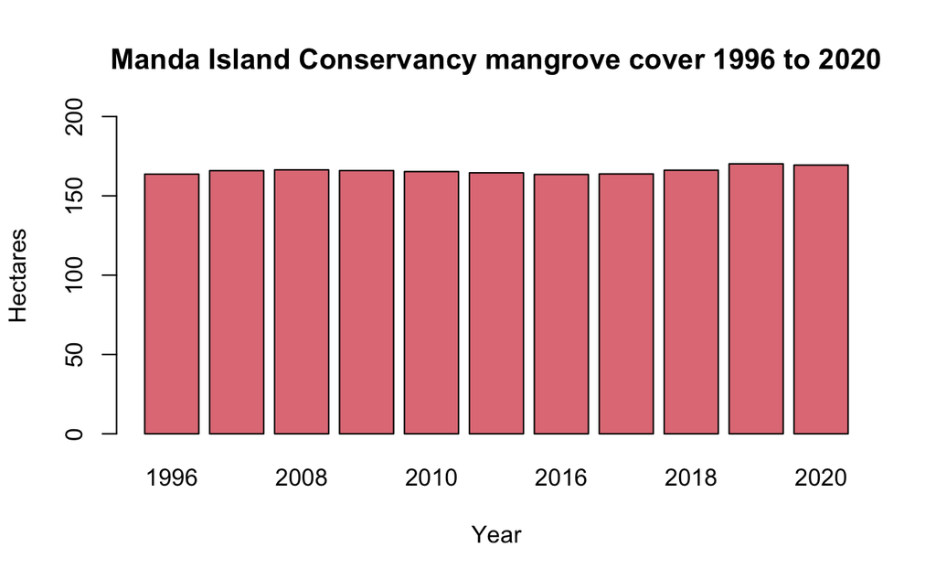

```r
# Uniform color
barplot(height=df4$total_mangroves_hectares, names=df4$year,
        col=rgb(0.8,0.1,0.1,0.6),
        xlab="Year",
        ylab="Hectares",
        main="Manda Island Conservancy mangrove cover 1996 to 2020",
        ylim=c(0,200)
        )
```

Create a time series

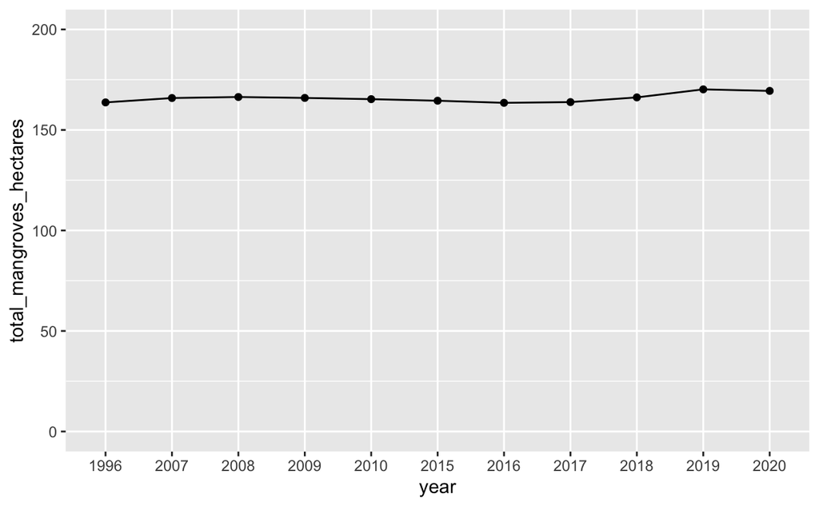

```r
df4 %>%
  ggplot( aes(x=year, y=total_mangroves_hectares, group=1)) +
    geom_line() +
    geom_point() +
  ylim(0, 200)
```

Export

```r
write.csv(df4, "~/Library/CloudStorage/OneDrive-UniversityofExeter/Global Sustainability Solutions/Dissertation/R/manda1996-2020.csv", row.names=FALSE)
```